# Data structures in R

## Case study

We have an Excel spreadsheet with some HIV/AIDS statistics from http://exploringdata.net/datasets.htm, and want to analyze the data in R. This is the story of the dataaset:

```
Story: AIDS and HIV Infections

This dataset contains the global estimate of cumulative AIDS and HIV cases worldwide, since 1980. One question that could be asked is if there is any slowing in the rate at which HIV and AIDS cases are occuring. Even after the data is transformed using logarithms there is still a strong upward trend in the residuals. Finding a model that fits the data may require looking more sophisticated functions than the usual exponential and polynomial functions. It would also be worth finding the number of new cases every year and modelling that growth. The relationship between the number of new HIV and AIDS cases might well be worth exploring. A dataset with rich potential.

Variables:

Year: year
HIV: Cumulative HIV infection (millions)
AIDS: Cumulative AIDS cases (millions)
Source: Compiled by Worldwatch Institute from: Global AIDS Policy Coalition, Harvard School of Public Health Boston, MA, discussion with author, 24 January 1997.
```

First, we must convert the spreadsheet into a simple format that R can import. We will choose to export to CSV (comma separated values).

Now we can read the CSV file into an R data frame

```r
aids <- read.csv("Duke2013A/aids.csv", header = TRUE)
```

Let's examine the imported data

```r
names(aids)
```

```
## [1] "Year"                    "HIV.Infection..million."
## [3] "AIDS.Cases..million."
```

```r
dim(aids)
```

```
## [1] 17  3
```

```r
head(aids)
```

```
##   Year HIV.Infection..million. AIDS.Cases..million.
## 1 1980                     0.2                  0.0
## 2 1981                     0.6                  0.0
## 3 1982                     1.1                  0.0
## 4 1983                     1.8                  0.1
## 5 1984                     2.7                  0.2
## 6 1985                     3.9                  0.4
```

```r
tail(aids)
```

```
##    Year HIV.Infection..million. AIDS.Cases..million.
## 12 1991                    15.5                  4.2
## 13 1992                    18.5                  5.5
## 14 1993                    21.9                  6.9
## 15 1994                    25.9                  8.5
## 16 1995                    30.6                 10.4
## 17 1996                    36.2                 12.5
```

```r
str(aids)
```

```
## 'data.frame':    17 obs. of  3 variables:
##  $ Year                   : int  1980 1981 1982 1983 1984 1985 1986 1987 1988 1989 ...
##  $ HIV.Infection..million.: num  0.2 0.6 1.1 1.8 2.7 3.9 5.3 6.9 8.7 10.7 ...
##  $ AIDS.Cases..million.   : num  0 0 0 0.1 0.2 0.4 0.7 1.1 1.6 2.3 ...
```

```r
summary(aids)
```

```
##       Year      HIV.Infection..million. AIDS.Cases..million.
##  Min.   :1980   Min.   : 0.2            Min.   : 0.00
##  1st Qu.:1984   1st Qu.: 2.7            1st Qu.: 0.20
##  Median :1988   Median : 8.7            Median : 1.60
##  Mean   :1988   Mean   :12.0            Mean   : 3.39
##  3rd Qu.:1992   3rd Qu.:18.5            3rd Qu.: 5.50
##  Max.   :1996   Max.   :36.2            Max.   :12.50
```

Note that we can extract each column of variables by name - the result is just a vector.

```r
aids$HIV
```

```
##  [1]  0.2  0.6  1.1  1.8  2.7  3.9  5.3  6.9  8.7 10.7 13.0 15.5 18.5 21.9
## [15] 25.9 30.6 36.2
```

The names of variables are rather cumbersome. Let's shorten them.

```r
names(aids) <- c("Year", "HIV", "AIDS")
names(aids)
```

```
## [1] "Year" "HIV"  "AIDS"
```

Often we want to deal with only a subset of the data. This is often done by relational filtering:

```r
aids.90s <- aids[aids$Year >= 1990, ]
aids.90s
```

```
##    Year  HIV AIDS
## 11 1990 13.0  3.2
## 12 1991 15.5  4.2
## 13 1992 18.5  5.5
## 14 1993 21.9  6.9
## 15 1994 25.9  8.5
## 16 1995 30.6 10.4
## 17 1996 36.2 12.5
```

We can also grow the data set by adding variables. Suppose we were interested in the ratio of AIDS to HIV cases for each year.

```r
aids$Ratio <- aids$AIDS/aids$HIV
head(aids)
```

```
##   Year HIV AIDS   Ratio
## 1 1980 0.2  0.0 0.00000
## 2 1981 0.6  0.0 0.00000
## 3 1982 1.1  0.0 0.00000
## 4 1983 1.8  0.1 0.05556
## 5 1984 2.7  0.2 0.07407
## 6 1985 3.9  0.4 0.10256
```

It is also good to get into the habit of visualizing your data.

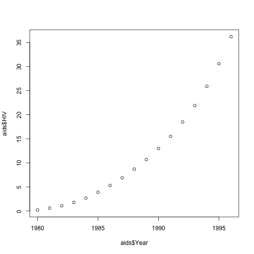

```r
plot(aids$Year, aids$HIV)
```

The plot looks rather ugly. Let's spruce it up a bit:

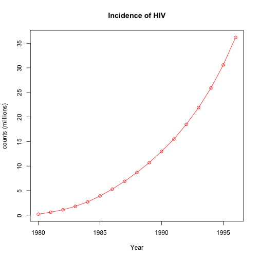

```r
plot(aids$Year, aids$HIV, type = "o", col = "red", main = "Incidence of HIV",
    xlab = "Year", ylab = "counts (milliions)")
```

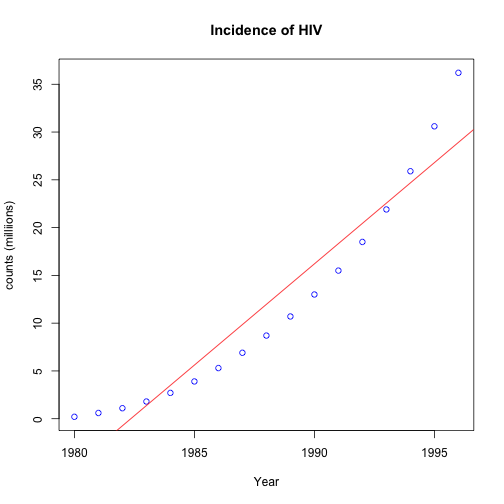

```r
fit1 <- lm(aids$HIV ~ aids$Year)
plot(aids$Year, aids$HIV, col = "blue", main = "Incidence of HIV", xlab = "Year",
    ylab = "counts (milliions)")
abline(fit1, col = "red")
```

That didn't work too well - let's try a quadratic fit.

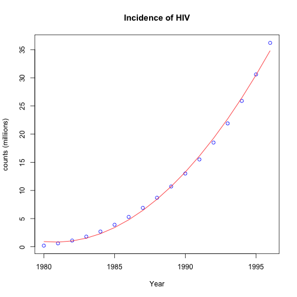

```r
fit2 <- lm(aids$HIV ~ poly(aids$Year, 2))
plot(aids$Year, aids$HIV, col = "blue", main = "Incidence of HIV", xlab = "Year",
    ylab = "counts (milliions)")
lines(aids$Year, predict(fit2, data.frame(x = aids$Year)), col = "red")
```

The fit is OK but not great since the residuals are definitely non-random. The data can be modeled and analyzed using nonlinear regression but that is outside the scope of this workshop.

## Exercise

Explore the relationship between smoking and cancer.

```
Story: Smoking and Cancer

Government statisticians in England conducted a study of the relationship between smoking and lung cancer. The data concern 25 occupational groups and are condensed from data on thousands of individual men. The explanatory variable is the number of cigarettes smoked per day by men in each occupation relative to the number smoked by all men of the same age. This smoking ratio is 100 if men in an occupation are exactly average in their smoking, it is below 100 if they smoke less than average, and above 100 if they smoke more than average. The response variable is the standardized mortality ratio for deaths from lung cancer. It is also measured relative to the entire population of men of the same ages as those studied, and is greater or less than 100 when there are more or fewer deaths from lung cancer than would be expected based on the experience of all English men.

Variable Names:

Occupation: occupation of the subjects
Smoke Index: relative ranking of amount of smoking, with 100 being average.
Cancer Index: relative ranking of deaths due to lung cancer, with 100 being average.
```